# Regression Models Course Project

### Relationship between a set of variables and MPG

#### Synopsis

Looking at the data set mtcars in R, this Report will analyse the the relationship between the variables of the data set and their effect on MPG. In particular the difference in MPG of automatic and manual transmission types is of interest. This report will quantify the difference in MPG for transmission types and will conclude, which transmission type is better for MPG, with higher MPG being better than lower MPG.

### Exploring the data

Variable “am” for transmission type. 0 = automatic, 1 = manual

```
##                    mpg cyl disp  hp drat    wt  qsec vs am gear carb
## Mazda RX4         21.0   6  160 110 3.90 2.620 16.46  0  1    4    4
## Mazda RX4 Wag     21.0   6  160 110 3.90 2.875 17.02  0  1    4    4
## Datsun 710        22.8   4  108  93 3.85 2.320 18.61  1  1    4    1
## Hornet 4 Drive    21.4   6  258 110 3.08 3.215 19.44  1  0    3    1
## Hornet Sportabout 18.7   8  360 175 3.15 3.440 17.02  0  0    3    2
## Valiant           18.1   6  225 105 2.76 3.460 20.22  1  0    3    1
```

Blue variables have negative correlation with MPG, thus, seem to increase fuel consumption.

### Fitting multiple models and detail strategy for model selection

We start with a linear model on mpg as the outcome and transmission type(am) as the predictor.

```
##              Estimate Std. Error   t value     Pr(>|t|)
## (Intercept) 17.147368   1.124603 15.247492 1.133983e-15
## factor(am)1  7.244939   1.764422  4.106127 2.850207e-04
```

It seems, that based on the coeffcients of our model, having a manual transmission improves MPG on average by 7.2, with a p-value of less than 1%. The measure for R-squared is 36%, which means, that our model only accounts for 36% of the variability around it’s mean. This means, that we might need more variables to better determine the impact of transmission types on MPG.

Next, we select all variables for the prediction of MPG.

```
##
## Call:
## lm(formula = mpg ~ ., data = mtcars)
##
## Residuals:
##     Min      1Q  Median      3Q     Max
## -3.4506 -1.6044 -0.1196  1.2193  4.6271
##
## Coefficients:
##             Estimate Std. Error t value Pr(>|t|)
## (Intercept) 12.30337   18.71788   0.657   0.5181
## cyl         -0.11144    1.04502  -0.107   0.9161
## disp         0.01334    0.01786   0.747   0.4635
## hp          -0.02148    0.02177  -0.987   0.3350
## drat         0.78711    1.63537   0.481   0.6353
## wt          -3.71530    1.89441  -1.961   0.0633 .
## qsec         0.82104    0.73084   1.123   0.2739
## vs           0.31776    2.10451   0.151   0.8814
## am           2.52023    2.05665   1.225   0.2340
## gear         0.65541    1.49326   0.439   0.6652
## carb        -0.19942    0.82875  -0.241   0.8122
## ---
## Signif. codes:  0 '***' 0.001 '**' 0.01 '*' 0.05 '.' 0.1 ' ' 1
##
## Residual standard error: 2.65 on 21 degrees of freedom
## Multiple R-squared:  0.869,  Adjusted R-squared:  0.8066
## F-statistic: 13.93 on 10 and 21 DF,  p-value: 3.793e-07
```

Taking all variables into account, having a manual transmission improves the MPG by 2.52. But it could be that we overfitted our model.

Taking the step function, to see which variables predict MPG the best.

Results are a model with weight, qsec and am as predictors.

Anova for 4 models, adding a model with weight and qsec as the only variables, to see if it fits better without transmission types.

```
## Analysis of Variance Table
##
## Model 1: mpg ~ factor(am)
## Model 2: mpg ~ wt + qsec + am
## Model 3: mpg ~ wt + qsec
## Model 4: mpg ~ cyl + disp + hp + drat + wt + qsec + vs + am + gear + carb
##   Res.Df    RSS Df Sum of Sq       F    Pr(>F)
## 1     30 720.90
## 2     28 169.29  2    551.61 39.2687 8.025e-08 ***
## 3     29 195.46 -1    -26.18  3.7271   0.06715 .
## 4     21 147.49  8     47.97  0.8537   0.56836
## ---
## Signif. codes:  0 '***' 0.001 '**' 0.01 '*' 0.05 '.' 0.1 ' ' 1
```

```
##
## Call:
## lm(formula = mpg ~ wt + qsec + am, data = mtcars)
##
## Residuals:
##     Min      1Q  Median      3Q     Max
## -3.4811 -1.5555 -0.7257  1.4110  4.6610
##
## Coefficients:
##             Estimate Std. Error t value Pr(>|t|)
## (Intercept)   9.6178     6.9596   1.382 0.177915
## wt           -3.9165     0.7112  -5.507 6.95e-06 ***
## qsec          1.2259     0.2887   4.247 0.000216 ***
## am            2.9358     1.4109   2.081 0.046716 *
## ---
## Signif. codes:  0 '***' 0.001 '**' 0.01 '*' 0.05 '.' 0.1 ' ' 1
##
## Residual standard error: 2.459 on 28 degrees of freedom
## Multiple R-squared:  0.8497, Adjusted R-squared:  0.8336
## F-statistic: 52.75 on 3 and 28 DF,  p-value: 1.21e-11
```

```
##                   2.5 %    97.5 %
## (Intercept) -4.63829946 23.873860
## wt          -5.37333423 -2.459673
## qsec         0.63457320  1.817199
## am           0.04573031  5.825944
```

On average, having a manual transmission, improves a cars MPG by 2.9 and an additional ton of weight, reduces MPG on average by 3.9. Slower acceleration, reported in qsec, improves MPG by 1.23, per additional second to finish a quater mile.

Looking at the residuals, we can see, that the points do not seem to be randomly distributed.

### Appendix

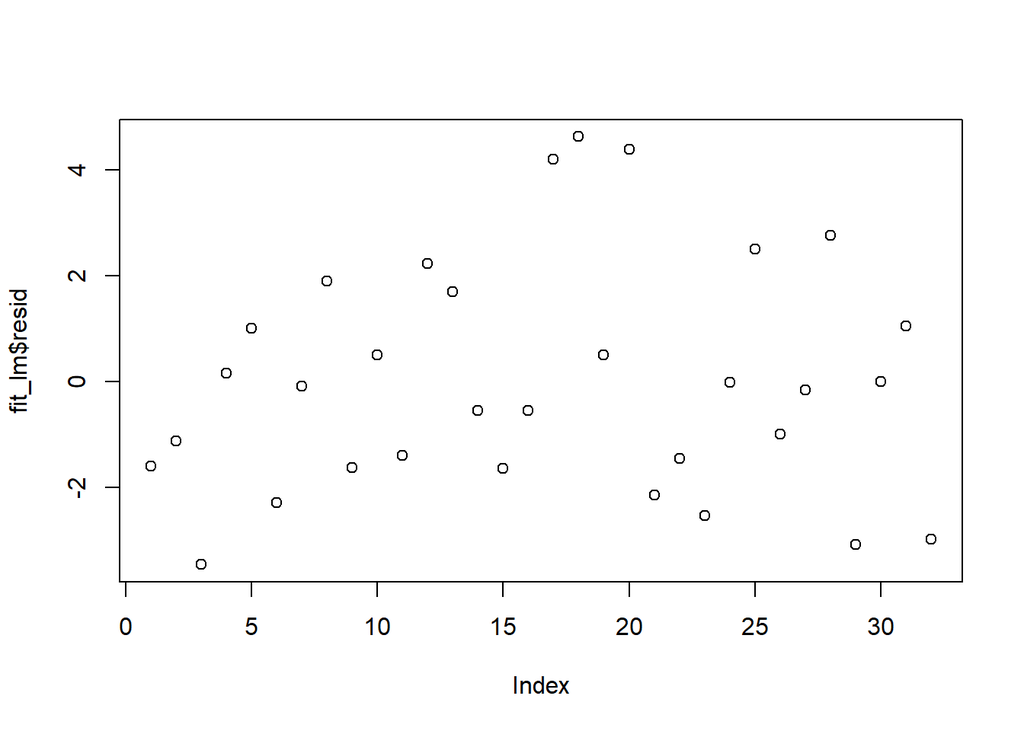

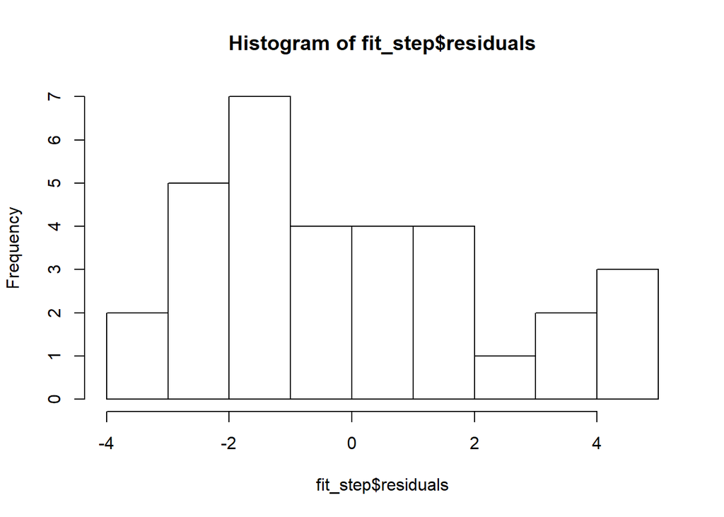

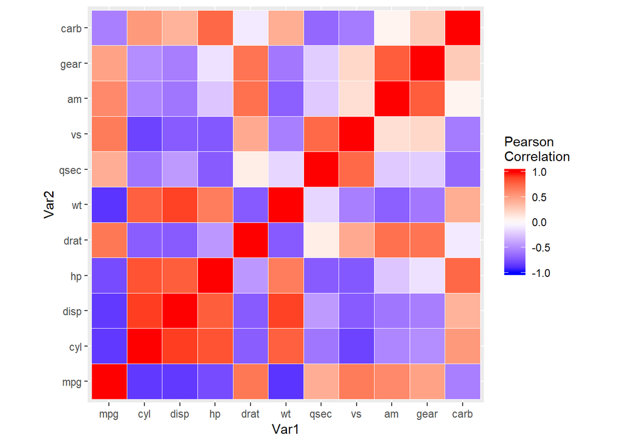

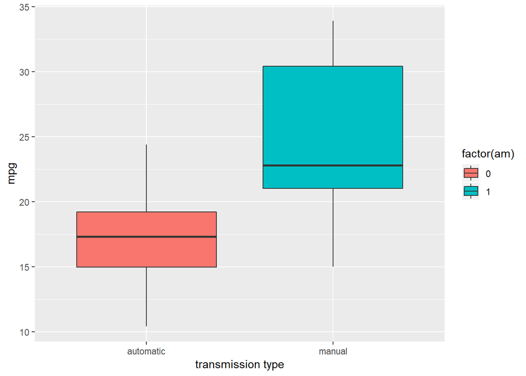

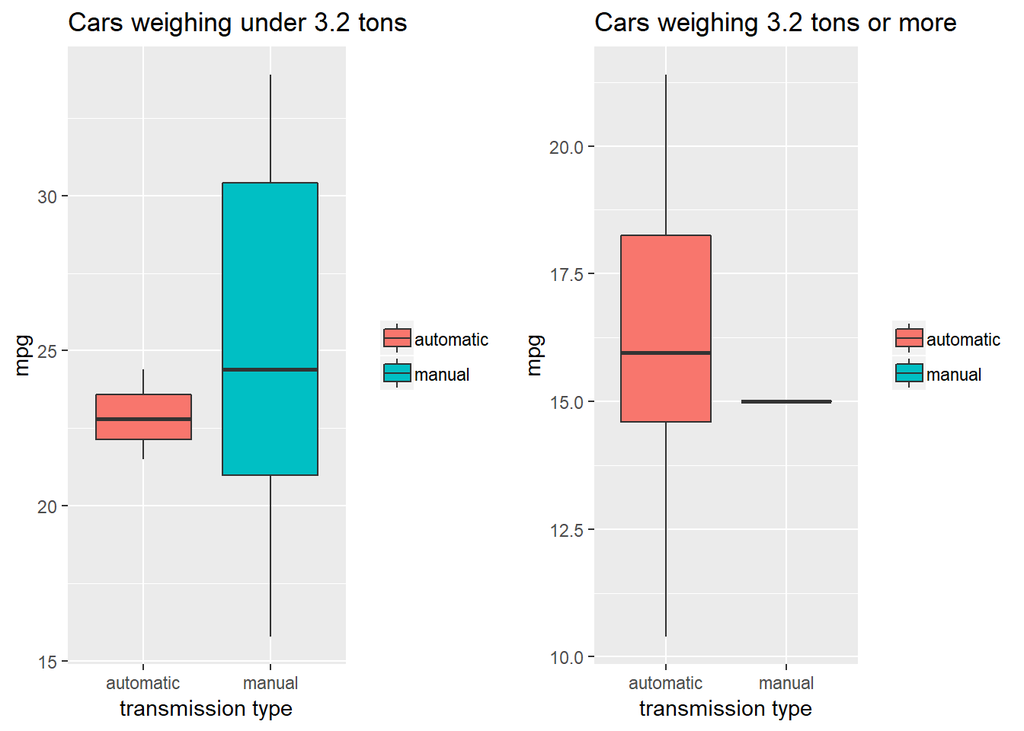